# Comments for MEDB 5502, Week 11, Hierarchical models

## Topics to be covered

- What you will learn
  - Hierarchical models
  - Hypothetical litter weights
  - Two sample t-test on first subset
  - Paired t-test on second subset
  - Variance components on third subset
  - Analysis of full dataset
  - Assumptions and complications

## Hierarchical data

- Moving beyond the independence assumption
- Correlation within clusters

## Examples of hierarchical data, 1 of 2

- Body parts
  - Left eye/right eye
  - Teeth
  - Skin patches
- Human families
- Animal litters

## Examples of hierarchical data, 2 of 2

- Clinics/hospitals
- Communities
- Repeated measurements

## Longitudinal data (topic for next module)

- Measurements taken at different times
  - Emphasis in changes over time

## Between and within cluster comparisons

- Positive correlation
  - Improves precision of within cluster comparisons
  - Hurts precision of between cluster comparisons
- Example with litters
  - Medication administered during pregnancy
  - Medication administered after birth

## Basic notation, 1 of 2

- $Y_{ij}$
  - i defines cluster
    - i=1,…,a
  - j defines individual within cluster
    - j=1,…,n

## Basic notation, 2 of 2

- $Y_{ij} = \mu+\alpha_i+\epsilon_{ij}$
  - $\mu$ unknown constant
  - $\alpha_i$ is normally distributed
    - $SD(\alpha_i)=\sigma_{between}$
  - $\epsilon_{ij}$ is normally distributed
    - $SD(\epsilon_i)=\sigma_{within}$

## Some basic results

- $SD(Y_{ij})=\sigma_{total} = \sqrt{\sigma^2_{between}+\sigma^2_{within}}$
- $SD(\bar{Y}_{..})=\sqrt{\frac{\sigma^2_{between}}{a}+\frac{\sigma^2_{within}}{an}}$
- $Corr(Y_{ij}, Y_{ik})=\frac{\sigma^2_{between}}{\sigma^2_{between}+\sigma^2_{within}}$
  - Intraclass correlation (ICC)

- $MS(within) = \frac{1}{a(n-1)}\Sigma_i\Sigma_j(\bar{Y}_{ij}-\bar{Y}_{i.})^2$
  - $E[MS(within)] = \sigma^2_{within}$

## Break #1

- What you have learned
  - Hierarchical models
- What’s coming next
  - Hypothetical litter weights

## Description of litter weights data, 1 of 3

```
data_dictionary: litter-weights.sav
```

```
description: |
  Hypothetical data simulated to  illustrate analysis issues  associated with random litter effects.
```

```
source: |
  Sobin, Christina; Golub, Mari (2020),  “Data for: Statistical Modeling with  Litter as a Random Effect in Mixed  Models to Manage Intralitter  Likeness”, Mendeley Data, V1,  doi: 10.17632/bwptvj2cmz.1
```

## Description of litter weights data, 2 of 3

```
ID:
  label: ID number for each animal
LITTER:
  label: ID number for each litter
SEX:
  label: Unspecified sex
  values:
  - 1
  - 2
```

## Description of litter weights data, 3 of 3

```
GRP:
  label: Unspecified group
  values:
  - 1
  - 2
  - 3
WGTP21:
  label: Weight
  units: Unspecified
```

## Break #2

- What you have learned
  - Hypothetical litter weights
- What’s coming next
  - Two sample t-test on first subset

## Subset1 of litter weights

- Consider only groups 1 and 2.
- Pick a male (sex=1) randomly from each litter
- Example of a between litter comparison

## Listing of subset

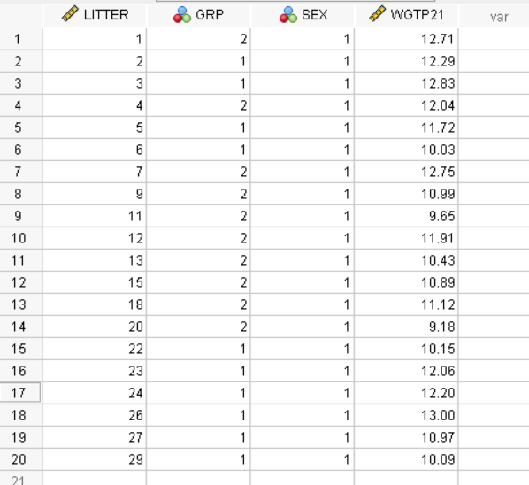

## Graph of subset

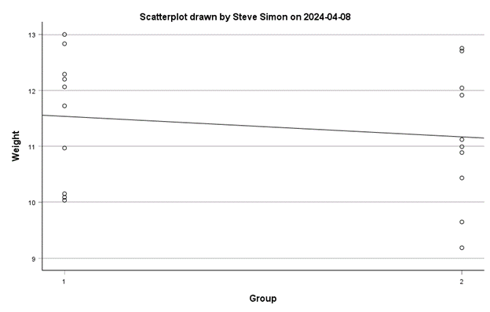

## Two-sample t-test

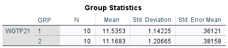

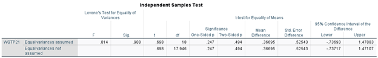

## Live demo, two sample t-test

## Break #3

- What you have learned
  - Two sample t-test on first subset
- What’s coming next
  - Paired t-test on second subset

## Subset2 of litter weights

- Only group 1
- Randomly select one male and one female
- Example of a within litter comparison

## Listing of subset

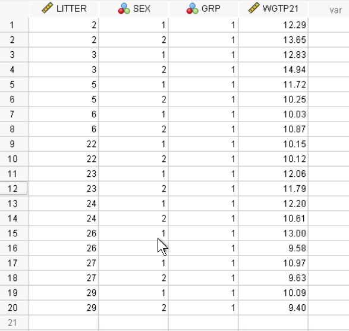

## Graph of data

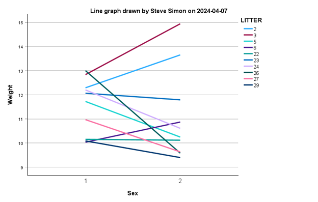

## Restructuring information

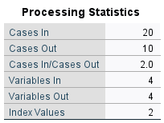

## View of data after restructuring

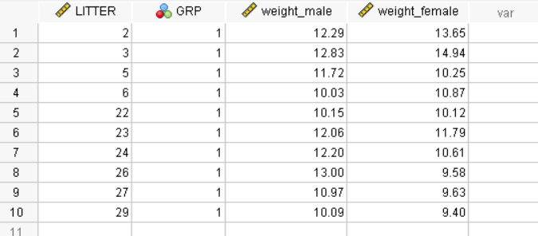

## Paired t-test

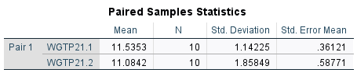

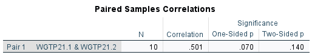

## Live demo, paired t-test and restructuring

## Break #4

- What you have learned
  - Paired t-test on second subset
- What’s coming next
  - Variance components on third subset

## Third subset

- Only group 1
- Only males (three per litter)
- Litter is a random factor
  - Represents a sample from a larger population
  - Intent to generalize to that population

## Partial listing of subset

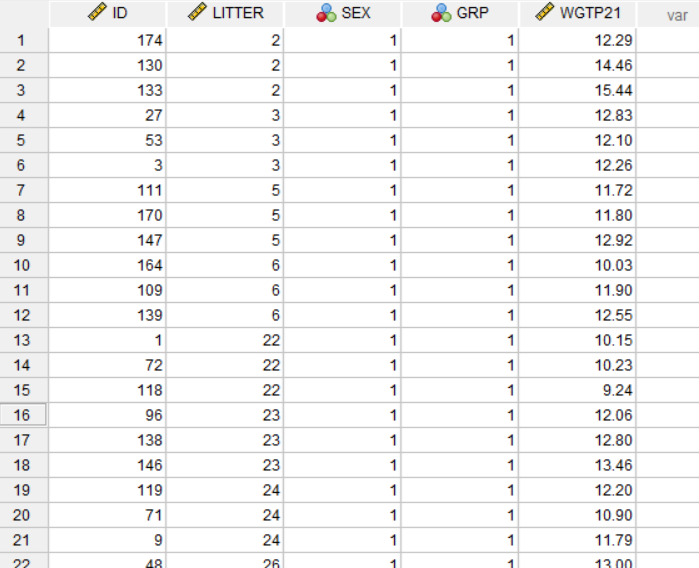

## Variance components, 1 of 2

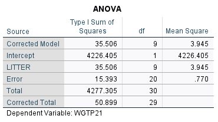

## Variance components, 2 of 2

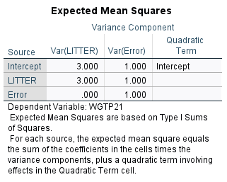

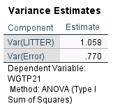

## Live demo, Variance components

## Break #5

- What you have learned
  - Variance components on third subset
- What’s coming next
  - Analysis of full dataset

## Analysis of full dataset

- Random factor
  - Litter Fixed factors
  - Sex
    - Within litter comparison
  - Group
    - Between litter comparison

## Variance components, 1 of 2

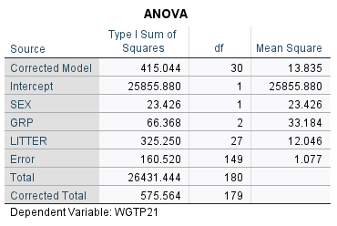

## Variance components, 2 of 2

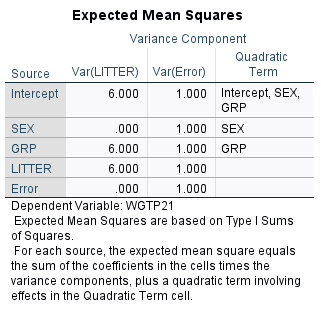

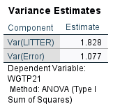

## Live demo, More variance components

## Break #6

- What you have learned
  - Analysis of full dataset
- What’s coming next
  - Assumptions and complications

## Assumptions

- Normality
  - Within clusters
  - Between clusters
- Independence
  - Only between clusters

## Complications

- Unbalanced data
- Interactions
- Multiple hierarchies

## Summary

- What you have learned
  - Hierarchical models
  - Hypothetical litter weights
  - Two sample t-test on first subset
  - Paired t-test on second subset
  - Variance components on third subset
  - Analysis of full dataset
  - Assumptions and complications